# Project: Investigate a Dataset - [Movies Dataset]

### Question 3 : What are the highest 5 movies in profit ?

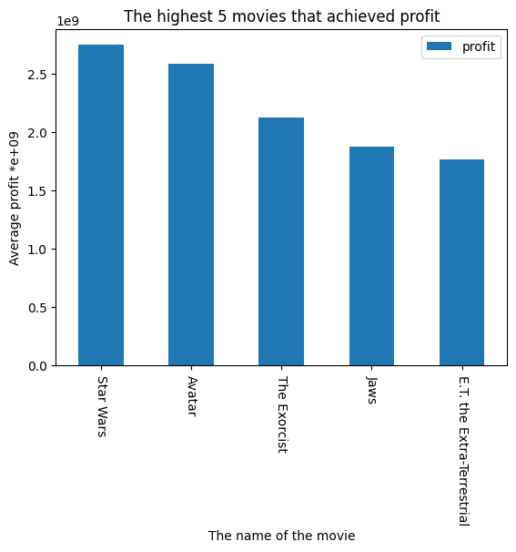

```python
#Making a dataframe for the title of each movie with the profit
#and sorting them then plotting the higher 5 in profit
data = pd.DataFrame(df_adj.groupby('original_title')['profit'].mean())
data.sort_values(by='profit', ascending = False, inplace = True)
data[:5].plot.bar(rot = 270, title = "The highest 5 movies that achieved profit", xlabel = "The name of the movie", ylabel = "Average profit *e+09")
```

```python
# Getting the profit of the highest movie that achieved profit(star wars)
df_adj[df['original_title'] == "Star Wars"]['profit']
```

```
1329    2.750137e+09
Name: profit, dtype: float64
```

> The highest movie in all of the movies that achieved profit was **Star Wars** which achieved 2.750137e+09 dollars

### Question 4 : Does the vote_average has a relation with the profit

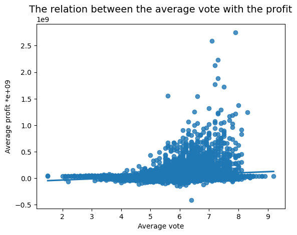

```python
#plotting in a seaborn scatter plot the vote average with the profit to see if there is a relation between them
data = sb.regplot(data = df_adj, x = 'vote_average', y = 'profit')
data.set_title("The relation between the average vote with the profit",size = 14)
data.set_ylabel("Average profit *e+09")
data.set_xlabel("Average vote")
```

> There is a direct relation between the vote and the profit achieved

## Conclusions

> ● To summarize, in this analysis we have asked **4 questions** about the data and answered them

> The conclusion of the analysis is :

> ● That the most 5 popular genres across the movies in a descending order are

> **Drama, Comedy, Thriller, Action, Romance**

> ● and there is no strong relation between **the genres** and the **average vote** of the film, the average vote of the genres is about 6

> ● there is a strong relation between the profit and the genre where the genre that achieve the highest profit among all the genres is **Adventure**

> ● The genre with the least average year is **Western which is 1986** and the genre with highest average year is **Documentry which is 2008**

> ● The highest movie in profit was **star wars** which achieved **2.750137e+09 dollars**

> ● The highest 5 movies in profit are **Star Wars, Avatar, The Exorcist, Jaws, The Extra-Terrestrial**

> ● In the final question, after Visualization I found that **there is a direct relation between the vote and the profit**, it means that when the average vote **increases** the profit **will probably increase**

> ● I suggest doing more description for the dataset like the description of each column and the range of values for each column

> and also filling the 0.0 values in the budget and revenue columns with the real values and also filling the Nan values in the rest of the columns with the real values

### Limitations:

> ● the first limitation that I have found that some of the values in the budget and revenue columns have values that equal zero which is not right so I filled them with the mean of the column which really affect the final mean of the column which affect the results of the exploratory data analysis which made it not very accurate so I suggest filling these values with the correct values to achieve more accurate analysis

> ● The second limitation that I have found is that no description for each column to limit the range of values that must be in every column and the others are outliers as an examale of this the popularity column which I didnt use it in the analysis for this reason so I suggest putting a description for each column and its limit of values

## Resources:

> [Pandas documentation](https://pandas.pydata.org/docs/reference/index.html#api)

> [Seaborn regplot](https://seaborn.pydata.org/generated/seaborn.regplot.html)